## 目標

- 滑らかにaからbまで変化する
- x=0で1になる

関数を定義する

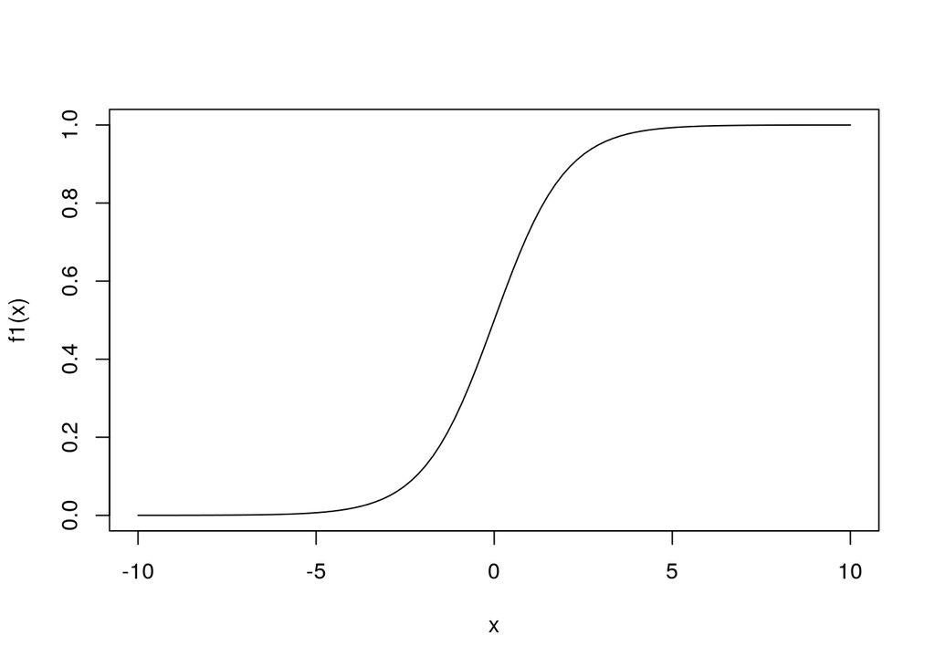

```r
f1 <- function(x){
  1/(1+exp(-x))
}

x <- seq(-10, 10, length.out = 100)
plot(x, f1(x), ty="l")
```

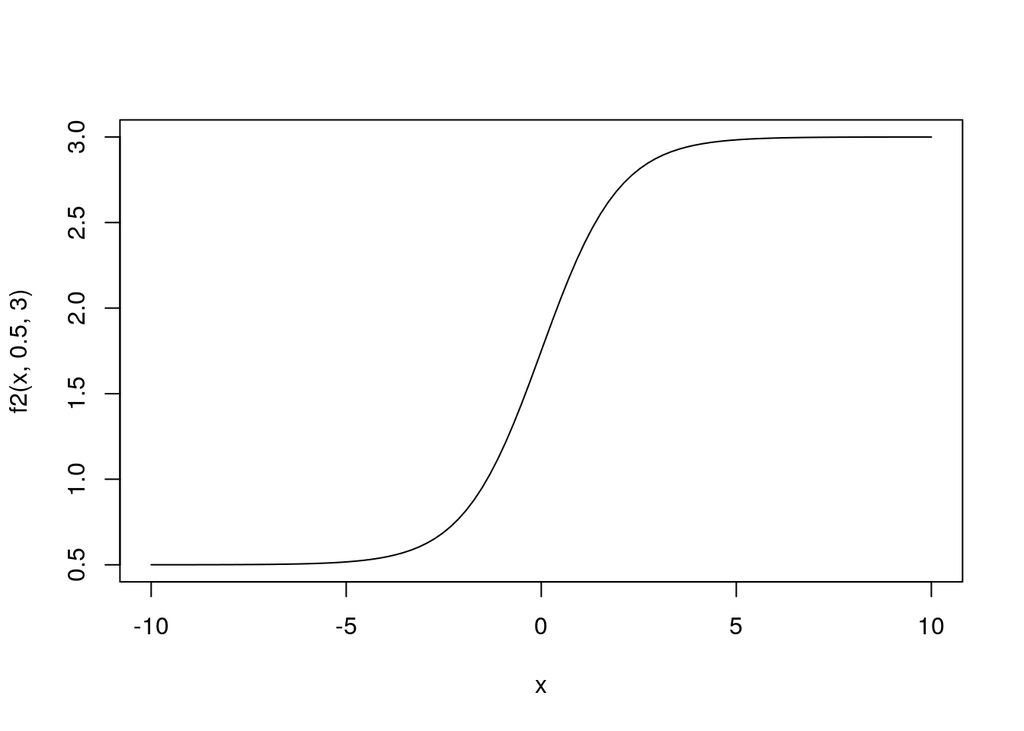

```r
f2 <- function(x, a, b){
  (b-a) * f1(x) + a
}

plot(x, f2(x, .5, 3), ty="l")
```

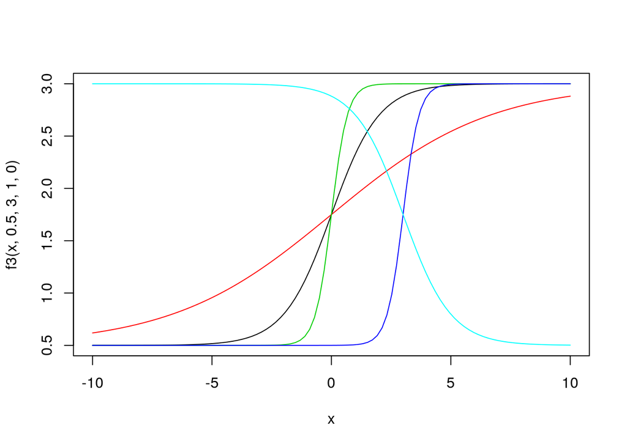

```r
f3 <- function(x, a, b, slope, pos){
  f2(slope*(x-pos), a, b)
}
plot(x, f3(x, 0.5, 3, 1, 0), ty="l")
lines(x, f3(x, 0.5, 3, 0.3, 0), col=2)
lines(x, f3(x, 0.5, 3, 3, 0), col=3)
lines(x, f3(x, 0.5, 3, 3, 3), col=4)
lines(x, f3(x, 0.5, 3, -1, 3), col=5)
```

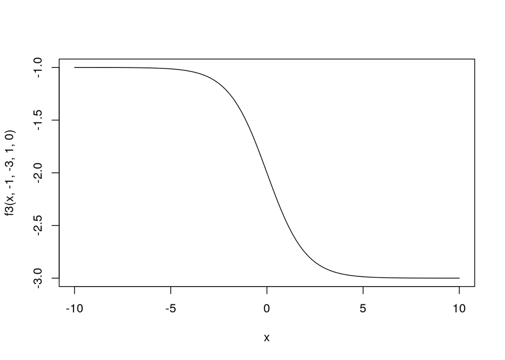

```r
plot(x, f3(x, -1, -3, 1, 0), ty="l")
```

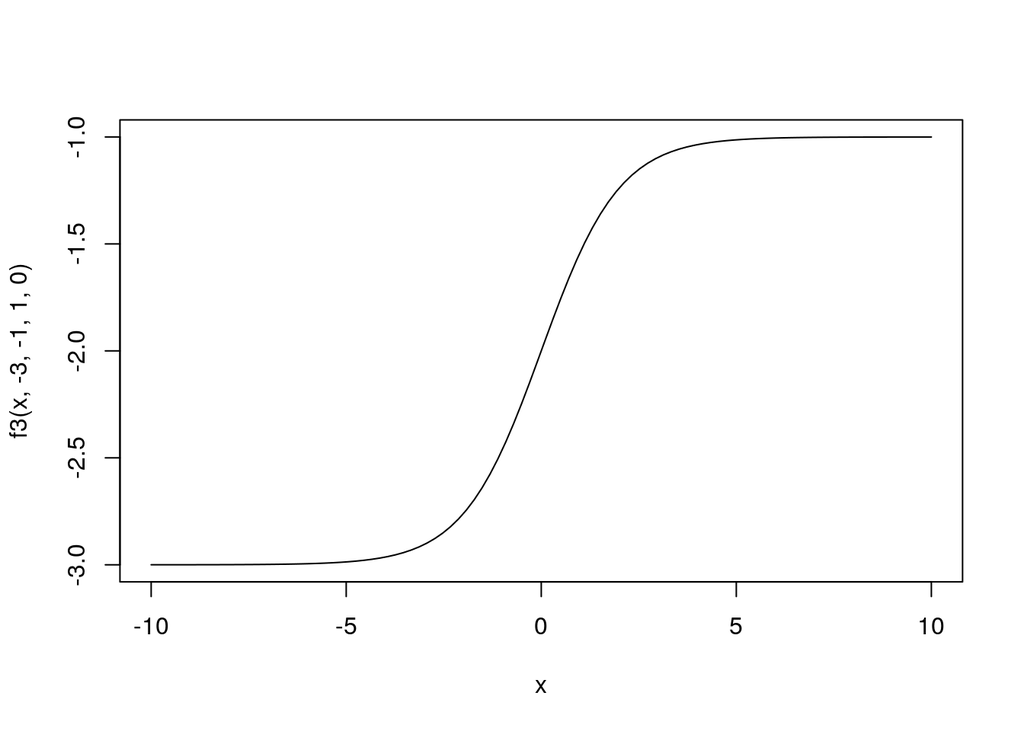

```r
plot(x, f3(x, -3, -1, 1, 0), ty="l")
```

## slopeとa,bの関係を考える

aは0に固定する

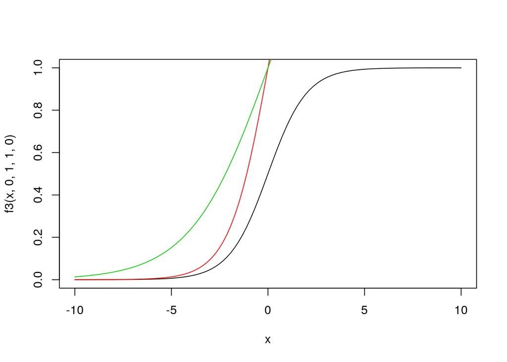

```r
plot(x, f3(x, 0, 1, 1, 0), ty="l") # 基本のライン
lines(x, f3(x, 0, 2, 1, 0), col=2) # bを2倍に
lines(x, f3(x, 0, 2, 0.5, 0), col=3) # 更にslopeを半分に
```

posとaが固定されていれば、線が重なり合うことはあまりない・・？

このparameterの撮り方だと、マイナス無限遠点でaというのが固定点になっている 0の時に1になるように固定したい。

`f3(x, a, b, slope, pos)` のposをいじることで、

- `f3(Inf, a, b, slope, pos(a, b, slope)) = b`
- `f3(-Inf, a, b, slope, pos(a, b, slope)) = a`
- `f3(0, a, b, slope, pos(a, b, slope)) = 1`

を満たすようにしたい。

```
f3(x, a, b, slope, pos) = f2( slope*(x - pos), a, b)
```

である。f2の造り方から、1,2番目の条件は自動的に満たされる。

```
f2( slope*(-pos(a, b, slope)), a, b) = 1
```

を満たすような `pos(a, b, slope)` を作ることができれば、条件を満たすことができる。

```
f2( slope*(-pos(a, b)), a, b) = 1
(b-a) * f1(-slope*pos(a,b)) + a = 1
f1(-slope*pos(a,b)) = (1-a) / (b-a)
-slope*pos(a,b) = f1^{-1}( (1-a)/(b-a) )
pos(a,b) = -f1^{-1}( (1-a)/(b-a) ) / slope
```

改めて定義すると。。

```r
f1inv <- function(y){
  log(y / (1 - y))
}
f5 <- function(x, a, b, slope){
  pos <- -f1inv( (1-a)/(b-a) ) / slope
  f3(x, a, b, slope, pos)
}
```

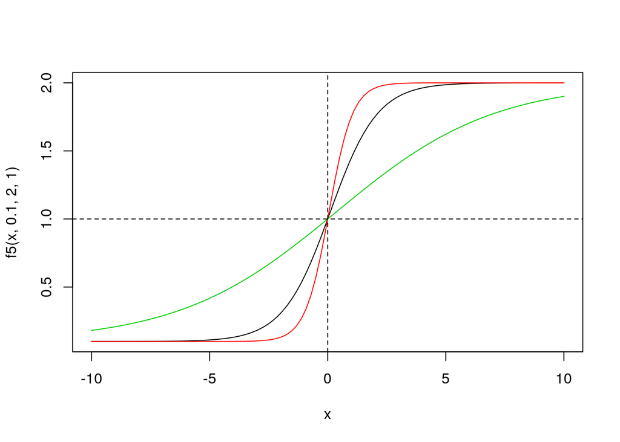

```r
plot(x, f5(x, 0.1, 2, 1), ty="l")
lines(x, f5(x, 0.1, 2, 2), col=2)
lines(x, f5(x, 0.1, 2, 0.3), col=3)
abline(h=1, lty=2)
abline(v=0, lty=2)
```

これで問題なさそう

a > bの場合は・・

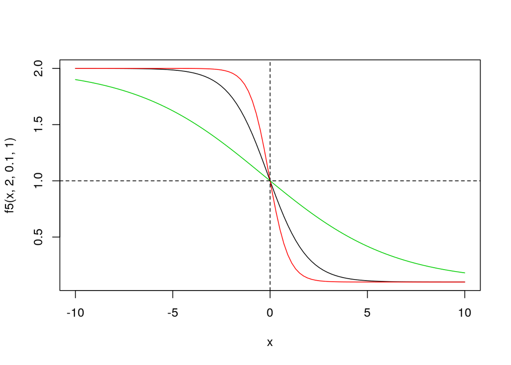

```r
plot(x, f5(x, 2, 0.1, 1), ty="l")
lines(x, f5(x, 2, 0.1, 2), col=2)
lines(x, f5(x, 2, 0.1, 0.3), col=3)
abline(h=1, lty=2)
abline(v=0, lty=2)
```

a < 0の場合は・・

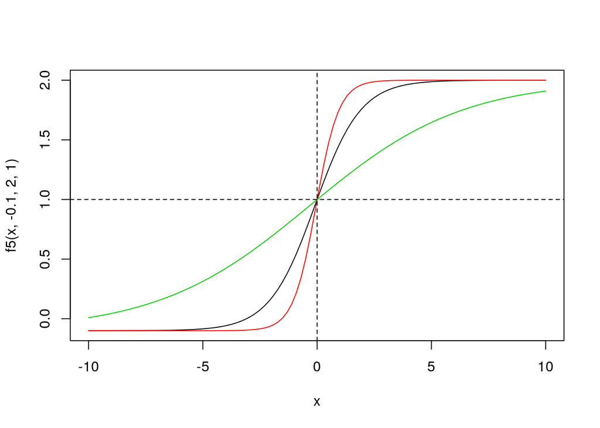

```r
plot(x, f5(x, -0.1, 2, 1), ty="l")
lines(x, f5(x, -0.1, 2, 2), col=2)
lines(x, f5(x, -0.1, 2, 0.3), col=3)
abline(h=1, lty=2)
abline(v=0, lty=2)
```

a, bから1までの距離が大きく違う場合

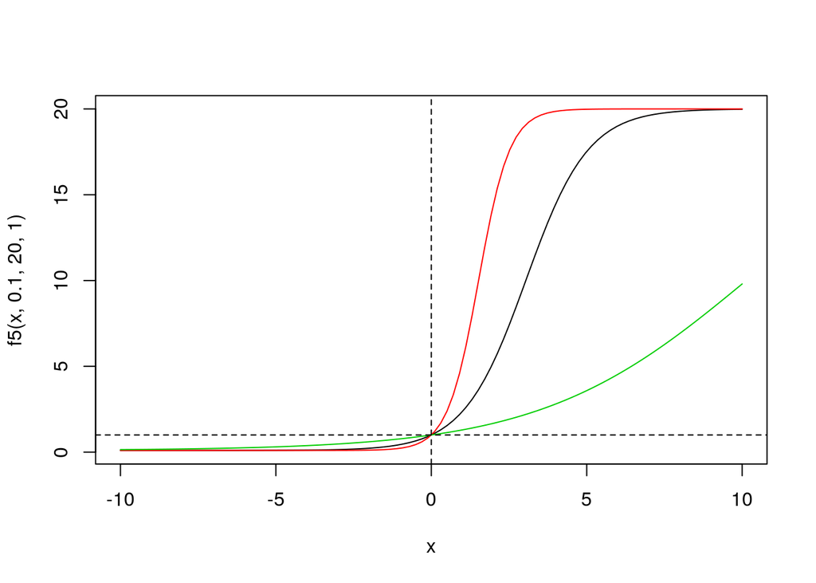

```r
plot(x, f5(x, 0.1, 20, 1), ty="l")
lines(x, f5(x, 0.1, 20, 2), col=2)
lines(x, f5(x, 0.1, 20, 0.3), col=3)
abline(h=1, lty=2)
abline(v=0, lty=2)
```

slopeとa, bを色々変えてみる

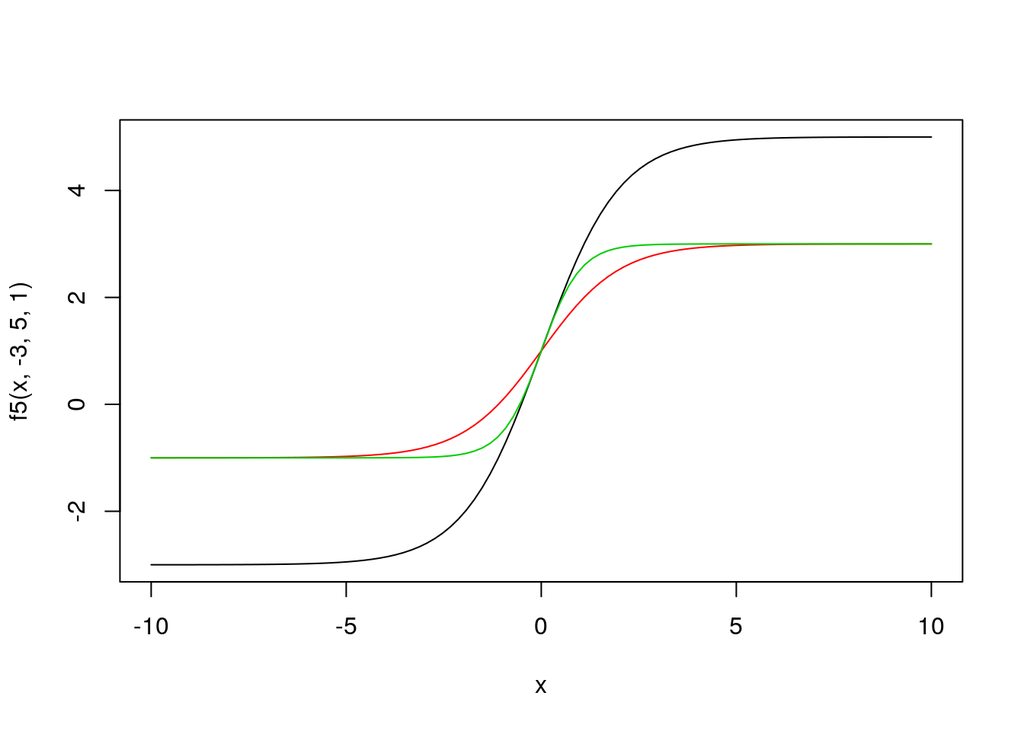

```r
plot(x, f5(x, -3, 5, 1), ty="l")
lines(x, f5(x, -1, 3, 1), col=2)
lines(x, f5(x, -1, 3, 2), col=3)
```

やっぱり0近傍で、a,bの幅を広げることとslopeを大きくすることの識別が困難になってる